# Pokemon Özelliklerinin Analizi

Armağan KESKİN && Cem KARAKUZU

ÖZET

Bu çalışmada Pokemonların tip,total,HP,Attack,Defense,Special attack ve defense,speed ve generation özelliklerine göre veri analizi yapılmıştır.Kendi tanımladığımız bir güç formülü ile Pokemonların gücünü belirledik ve bunu bir değişken olarak verimize ekledik.Verimizde Type.1 ve Type.2 şeklinde iki özellik bulunmaktaydı.İlk olarak ortak iki gruba ait olan Pokemonların grafiğini çıkardık.Daha sonra tanımladığımız güç değişkeninin tiplere göre ortalama dağılımını histogram grafiğinde gösterdik.Ayrıca doğrusal regresyon analizi ile güç değişkenini special attack özelliği ile tahmin etmeye çalıştık.Son olarak ise toplam 6 nesildeki pokemon sayılarını sütun yardımıyla görselleştirdik.

Hazırlık

İlk olarak kullanacağımız kütüphaneleri kodumuza library fonksiyonu yardımı ile dahil ettik ve çalışma klasörümüzü belirledik.Daha sonra ise analiz edilecek veri setimizi okuduk.

```r
library(rpart)
library(rpart.plot)
library(data.table)
library(tidyverse)
library(ggplot2)
setwd("/home/armik/Downloads")
veri=read.csv("Pokemon.csv",header=TRUE,sep=",")
head(veri)
```

|  | X. | Name | Type.1 | Type.2 | Total | HP | Attack | Defense | Sp..Atk | Sp..Def | Speed | Generation | Legendary |
| --- | --- | --- | --- | --- | --- | --- | --- | --- | --- | --- | --- | --- | --- |
| 1 | 1 | Bulbasaur | Grass | Poison | 318 | 45 | 49 | 49 | 65 | 65 | 45 | 1 | False |
| 2 | 2 | Ivysaur | Grass | Poison | 405 | 60 | 62 | 63 | 80 | 80 | 60 | 1 | False |
| 3 | 3 | Venusaur | Grass | Poison | 525 | 80 | 82 | 83 | 100 | 100 | 80 | 1 | False |
| 4 | 3 | VenusaurMega Venusaur | Grass | Poison | 625 | 80 | 100 | 123 | 122 | 120 | 80 | 1 | False |
| 5 | 4 | Charmander | Fire |  | 309 | 39 | 52 | 43 | 60 | 50 | 65 | 1 | False |
| 6 | 5 | Charmeleon | Fire |  | 405 | 58 | 64 | 58 | 80 | 65 | 80 | 1 | False |

Analiz ve Sonuç

```r
veri %>% rowwise() %>%
  mutate(Type=paste0(Type.1," ",Type.2),Type=gsub(" +$","",Type)) %>% tbl_df()
```

| X. | Name | Type.1 | Type.2 | Total | HP | Attack | Defense | Sp..Atk | Sp..Def | Speed | Generation | Legendary | Type |
| --- | --- | --- | --- | --- | --- | --- | --- | --- | --- | --- | --- | --- | --- |
| 1 | Bulbasaur | Grass | Poison | 318 | 45 | 49 | 49 | 65 | 65 | 45 | 1 | False | Grass Poison |
| 2 | Ivysaur | Grass | Poison | 405 | 60 | 62 | 63 | 80 | 80 | 60 | 1 | False | Grass Poison |
| 3 | Venusaur | Grass | Poison | 525 | 80 | 82 | 83 | 100 | 100 | 80 | 1 | False | Grass Poison |
| 3 | VenusaurMega Venusaur | Grass | Poison | 625 | 80 | 100 | 123 | 122 | 120 | 80 | 1 | False | Grass Poison |
| 4 | Charmander | Fire |  | 309 | 39 | 52 | 43 | 60 | 50 | 65 | 1 | False | Fire |
| 5 | Charmeleon | Fire |  | 405 | 58 | 64 | 58 | 80 | 65 | 80 | 1 | False | Fire |
| 6 | Charizard | Fire | Flying | 534 | 78 | 84 | 78 | 109 | 85 | 100 | 1 | False | Fire Flying |
| 6 | CharizardMega Charizard X | Fire | Dragon | 634 | 78 | 130 | 111 | 130 | 85 | 100 | 1 | False | Fire Dragon |
| 6 | CharizardMega Charizard Y | Fire | Flying | 634 | 78 | 104 | 78 | 159 | 115 | 100 | 1 | False | Fire Flying |
| 7 | Squirtle | Water |  | 314 | 44 | 48 | 65 | 50 | 64 | 43 | 1 | False | Water |

[output cut: 790 more lines]

```
Ignoring unknown parameters: binwidth, bins, pad
```

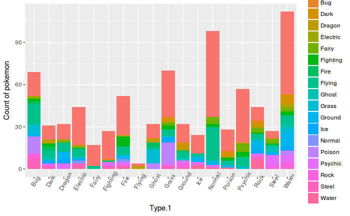

```r
veri2=veri %>%
  mutate(guc = 4*HP + 3*(Attack + Sp..Atk)+ 2*(Defense + Sp..Def) + Speed) # Tanımlanan Güç
type = veri %>%
  select(Type.1,Type.2)%>%
  group_by(Type.1,Type.2)%>%summarise(count=n())
type%>%
  filter(!(Type.2 =="  "))%>%
  ggplot(aes(x=Type.1,y=count,fill=Type.2))+geom_histogram(stat="identity",position="stack")+theme(axis.text.x = element_text(angle=60))+labs(y="Count of pokemon")
```

Yukarıdaki histogram grafiğinde iki tipteki pokemon sayıları gösterilmiştir.

```
Ignoring unknown parameters: binwidth, bins, pad
```

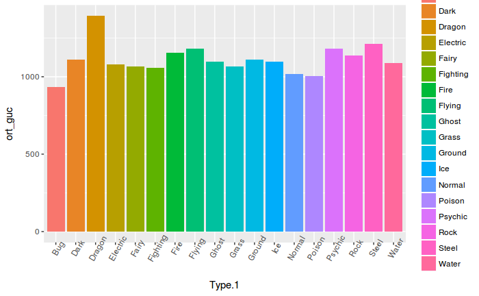

```r
ortalama = veri2 %>%
  group_by(Type.1) %>%
  summarise(ort_guc = mean (guc))
ortalama %>%
  ggplot(aes(x=Type.1,y=ort_guc))+geom_histogram(stat = "identity",position="stack",aes(fill=Type.1))+theme(axis.text.x = element_text(angle=60))
```

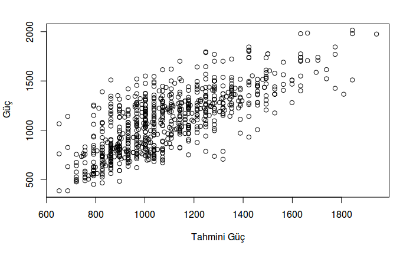

```r
regr = lm(guc~Sp..Atk,veri2)
plot(regr$fitted.values,veri2$guc,xlab='Tahmini Güç',ylab = ' Güç')
```

Bu grafikte ise her tipin ortalama gücü gösterilmiştir.Special attack değişkeni ile gücü tahmin etmeye çalıştık.Bunun için de doğrusal regresyon analizi uyguladık.

```r
summary(regr)
```

```
Call:
lm(formula = guc ~ Sp..Atk, data = veri2)

Residuals:
    Min      1Q  Median      3Q     Max
-613.09 -152.59  -18.43  129.05  648.05

Coefficients:
            Estimate Std. Error t value Pr(>|t|)
(Intercept) 581.2440    17.7093   32.82   <2e-16 ***
Sp..Atk       7.0176     0.2218   31.63   <2e-16 ***
---
Signif. codes:  0 ‘***’ 0.001 ‘**’ 0.01 ‘*’ 0.05 ‘.’ 0.1 ‘ ’ 1

Residual standard error: 205.2 on 798 degrees of freedom
Multiple R-squared:  0.5563,    Adjusted R-squared:  0.5558
F-statistic:  1001 on 1 and 798 DF,  p-value: < 2.2e-16
```

Analizin özetinde de gözüktüğü üzere Special attack’ın gücü tahmin etmemizde istatiksel olarak anlamlı bir değişken olduğu sonucu çıkmıştır.Etki büyüklüğü 0.55 ile yüksek bir etkiye sahiptir.

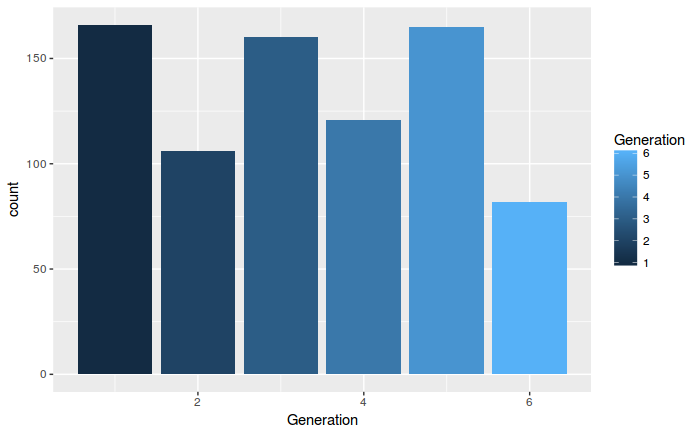

```r
generation_grafik <-
  veri2 %>%
  group_by(Generation) %>%
  summarise(count=n()) %>%
  ggplot(.,aes(x=Generation,y=count)) + geom_bar(stat="identity",aes(fill=Generation))
generation_grafik
```

Bu grafikte ise nesillerdeki pokemon sayılarını sütun grafiği sayesinde gösterdik.

```
All boxes will be white (the box.palette argument will be ignored) because
the number of classes predicted by the model 18 is greater than length(box.palette) 6.
To make this warning go away use box.palette=0 or trace=-1.
```

[figure not shown]

```r
tahmin_agacı <- rpart(Type.1~.,veri2[-c(1,2,11)],method = "class")
rpart.plot(tahmin_agacı)
```